# About

Teddy Landis

For my project, I am looking at the effect first-time voting type has on future voting behaviors. If someone’s first possible vote (i.e. the first possible election they can vote in after they turn 18), is cast through an absentee ballot, does that affect their likelihood of voting in future elections?

My data comes from two datasets provided by the [North Carolina Secretary of State](https://www.ncsbe.gov/Public-Records-Data-Info/Election-Results-Data) . I am using data from North Carolina because they provide both voter registration records and voter history for free on their website. I will design my project using the datasets for Alamance county, but once my project is built I will use the Statewide datasets. The statewide dataset is very large and slows my computer - I would rather wait until the end of my project to use it. Instructions on how to access this data are available in README.

Dataset 1 is alamance_hist (ncvhis1.txt). It is a .txt file that I downloaded from the North Carolina Secretary of State. It contains records for each vote cast. Dataset 2 is almanace_reg (ncvoter1.txt) and it contains each voter’s voter registration record. Both contain a “voter registration number” which I can use to merge the datasets. The statewide datasets are identical but include more observations.

My repository can be found [here](https://github.com/tlandis212/final_project).

*Milestone 4 Update*: I further cleaned up my datafile. It is now smaller and only includes essential variables.

My plan is to create topline descriptions of how many people voted in each election after the previous one.

## Exploring the Dataset

| voting_method | count |
| --- | --- |
| ABSENTEE BY MAIL | 12680 |
| ABSENTEE CURBSIDE | 3214 |
| ABSENTEE ONESTOP | 186525 |
| CURBSIDE | 3039 |
| IN-PERSON | 271801 |
| PROVISIONAL | 1729 |
| TRANSFER | 1903 |
| NA | 20641 |

## Milestone 5

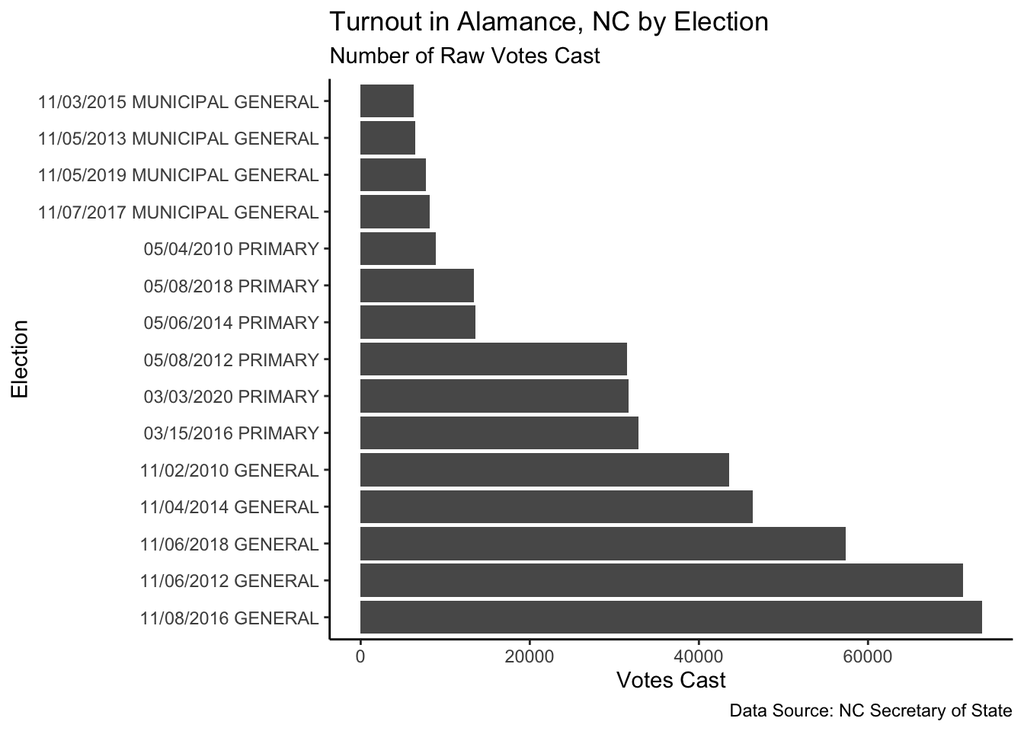

## Milestone 6

[figure not shown]

```r
# Play around with aes() in the ggplot with combinations of outcome_2014 and treatment.
  # Count of XX Year total votes divided by count of treatment votes

    ggplot(ms_six_b, aes(x = treatment)) +
  geom_bar(aes(y = (..count..)/(..count..)), fill = "red") +
    scale_y_continuous(labels=scales::percent) +
   theme_classic() +
  labs(x = "Voting Method",
       y = "Percent of Voters",
       title = "Voting in the 2012 General Election",
       subtitle = "18-year-old Voters from Alamance County, NC")
```

```r
ms_six <- ms_six_b %>%
  mutate(treatment_2014 = ifelse(treatment == "Absentee" & gelection_2014 != "No Vote", TRUE, FALSE),
         control_2014 = ifelse(treatment == "In Person/Early Vote" & gelection_2014 != "No Vote", TRUE, FALSE))

ms_six %>%
  count(control_2014)
```

```
## # A tibble: 2 x 2
##   control_2014     n
##   <lgl>        <int>
## 1 FALSE          608
## 2 TRUE           185
```

```r
count_voted_2012 <- ms_six %>%
  filter(treatment == "Absentee") %>%
  count() %>%
  pull()

count_voted_2014 <- ms_six %>%
  filter(treatment_2014 == "TRUE") %>%
  count() %>%
  pull()

treatment_2014_x <- count_voted_2014 / count_voted_2012

count_voted_2012_control <- ms_six %>%
  filter(treatment == "In Person/Early Vote") %>%
  count() %>%
  pull()

count_voted_2014_control <- ms_six %>%
  filter(control_2014 == "TRUE") %>%
  count() %>%
  pull()

control_2014_x <- count_voted_2014_control / count_voted_2012_control
```

[figure not shown]

```r
ggplot(ms_six, aes(x = outcome_2014, fill = treatment)) +
  geom_bar(aes(y = (control_2014_x)/(..count..))) +
  scale_y_continuous(labels=scales::percent) +
  theme_classic() +
  labs(x = "Voting Method",
       y = "Percent of Voters",
       title = "Voting Method in the 2014 General Election",
       subtitle = "20-year-old Voters from Alamance County, NC")
```

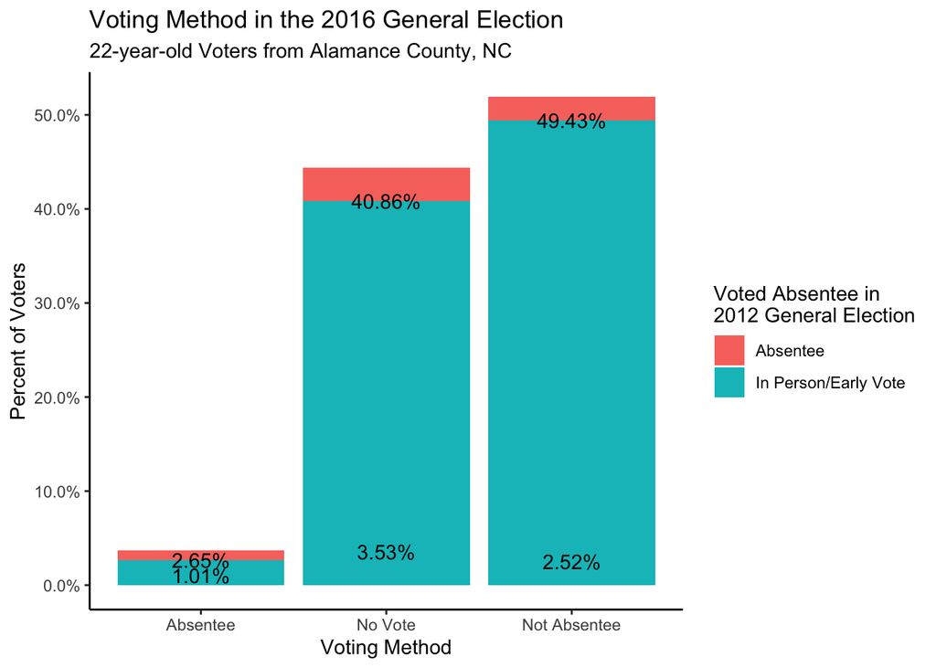

```r
ggplot(ms_six, aes(x = gelection_2016, fill = treatment)) +
  geom_bar(aes(y = (..count..)/sum(..count..))) +
  scale_y_continuous(labels=scales::percent) +
  geom_text(aes( label = scales::percent((..count..)/sum(..count..)),
  y= (..count..)/sum(..count..)), stat= "count", vjust = .5) +
  theme_classic() +
  labs(x = "Voting Method",
       y = "Percent of Voters",
       title = "Voting Method in the 2016 General Election",
       subtitle = "22-year-old Voters from Alamance County, NC",
       fill = "Voted Absentee in\n2012 General Election")
```